# RAW Fisherman Task

Andrew Gerlach

2025-01-30

# Setup

## Set options…

```
## Excluding participants with marginal data
```

## Read in and preprocess data…

# Basic Quality Checks

## Verify data matches expected format…

```
##
## WARNING: fish mismatches detected, apply FISH_mismatch to see mismatched rows
##     (only true for first 4 participants with known mislabeled sequences)
```

## Check catch blocks (blocks 11 and 20)…

[output not shown]

[output cut: 19 more lines]

[output not shown]

# Model data

## Generate ideal Bayesian model…

Use `plot_subject()` to visualize idealized and empirical performance for a subject, e.g.:

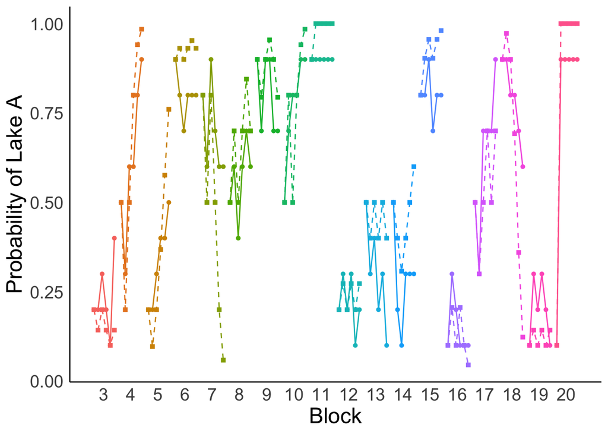

# Exclude subjects with abberent behavior…

# Behavioral exploration

## Add behavioral quantification…

## Fit parameterized Bayesian model…

## Clinical associations of behavior

### Prior strength

NOTE! The following plots show the MEAN prior weight for the moderate prior only. The reported statistics are for trial level data, but such data does not make for an informative plot.

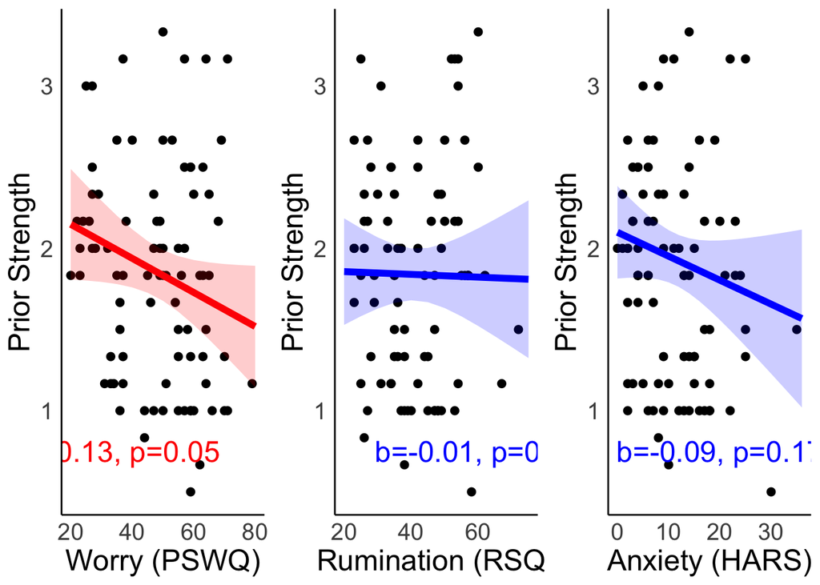

PSWQ has an inverse association with the weight given to priors (i.e., greater worry severity is associated with less weight given to the priors). In mixed-effects models, greater PSWQ is associated with lower weights (t=-1.9206692, p=0.0547734). RSQ does not have an association with prior weight. HARS appears to have an inverse association with the weight, but this is not statistically significant (t=-1.37, p=0.17)

AI added 9/9/2025: prior1 only considers the prior when the fisherman’s in the medium position (prior2 is when he’s in the extreme condition). The model without a number is the one that considers it all and is reported.

### Model fit

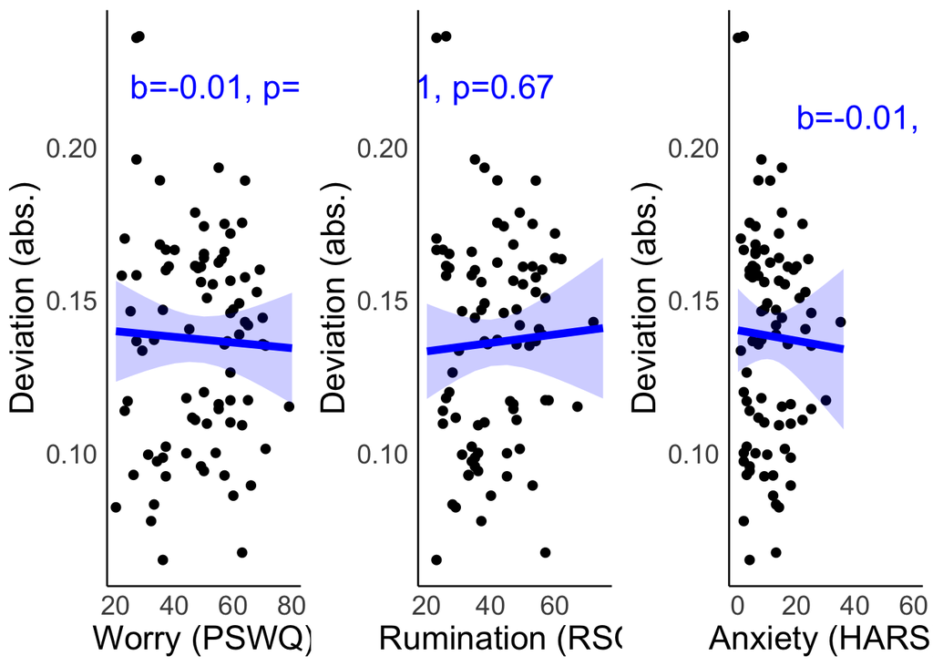

There does not appear to be any association between deviations from the Bayesian fully optimal updates and PSWQ, RSQ, or HARS.

### Bayesian parameterization

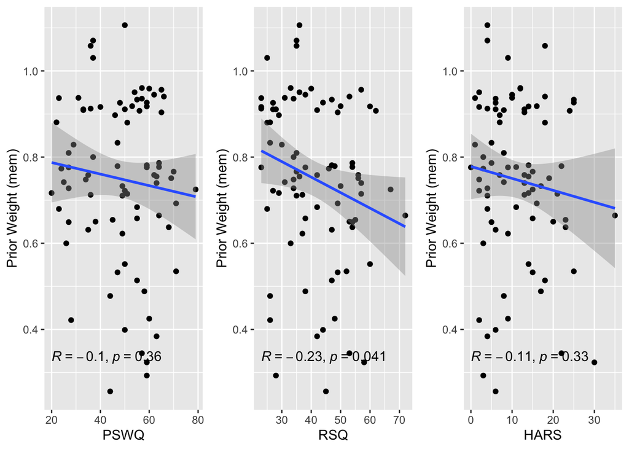

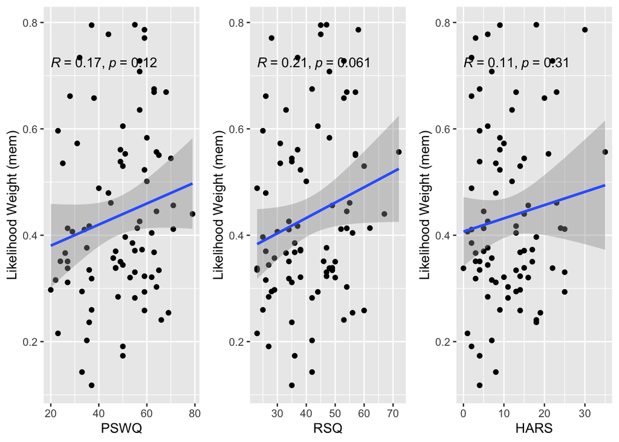

```
##
## Call:
## lm(formula = prior_likelihood_diff_mem ~ pswq + rsq + hars, data = .)
##
## Residuals:
##     Min      1Q  Median      3Q     Max
## -2.4432 -0.4008  0.1419  0.6216  1.8376
##
## Coefficients:
##              Estimate Std. Error t value Pr(>|t|)
## (Intercept) -0.009121   0.108704  -0.084    0.933
## pswq        -0.007202   0.135595  -0.053    0.958
## rsq         -0.322921   0.153859  -2.099    0.039 *
## hars         0.137282   0.147465   0.931    0.355
## ---
## Signif. codes:  0 '***' 0.001 '**' 0.01 '*' 0.05 '.' 0.1 ' ' 1
##
## Residual standard error: 0.9901 on 79 degrees of freedom
##   (1 observation deleted due to missingness)
## Multiple R-squared:  0.06586,    Adjusted R-squared:  0.03038
## F-statistic: 1.857 on 3 and 79 DF,  p-value: 0.1438
```

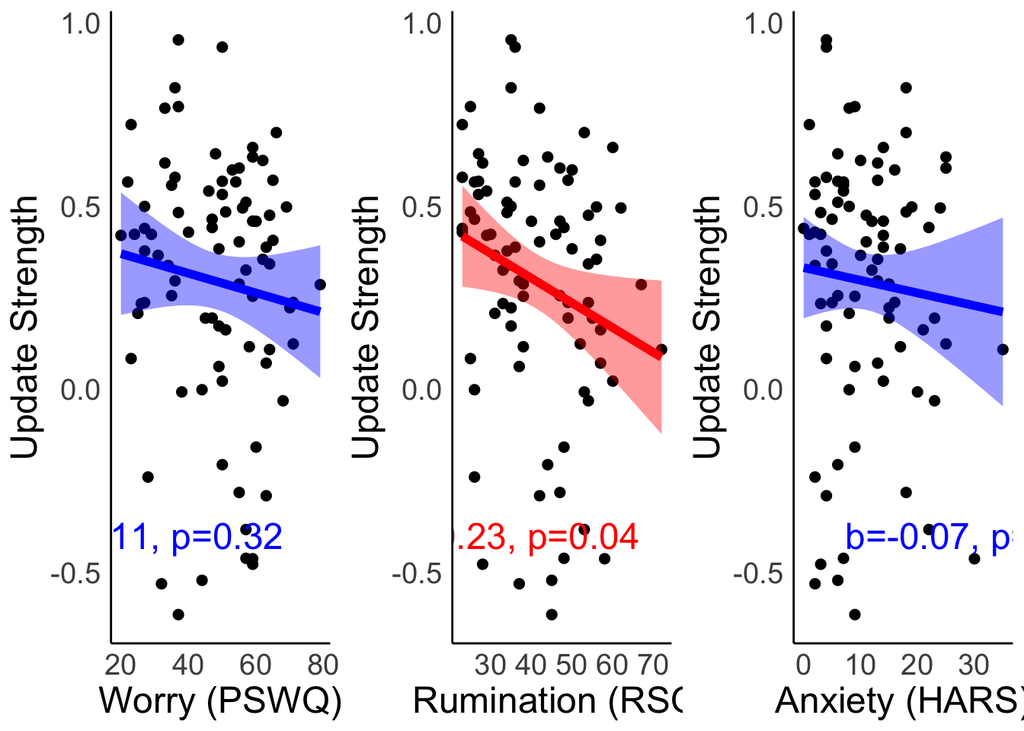

# AI - Cognition

dat is the original data file; not exactly sure what is done for dat3 (block 19 only?) dat2$prior_likelihood_diff_lm = dat2$prior_weight_lm - dat2$likelihood_weight_lm mod <- lmer(log(prob_A) ~ (1 + log(trial_prior) + log(like_A) | subject), dat) dat3 <- dat2 %>% filter(block == 19) %>% select(-block) dat3 <- cbind(dat3, coef(mod)$subject) names(dat3)[(ncol(dat3) - 2) : ncol(dat3)] <- c(“prior_weight_mem”, “likelihood_weight_mem”, “marginal_weight_mem”) dat3$prior_likelihood_diff_mem <- dat3$prior_weight_mem - dat3$likelihood_weight_mem

Behavioral variables of interest: prior_strength (from dat), prior_mean? (from dat3), prior_likelihood_diff_mem (from dat3; this is subject specific, not trialwise) Update strength: dat3$prior_likelihood_diff_mem <- dat3$prior_weight_mem - dat3$likelihood_weight_mem Deviation from bayesian optimal and prior weight are trial specific, update strength is subject specific

Cognitive variables of interest, from Andrea: Visuospatial, skeptical eye: line orientation, figure copy - RBANS Visuospatial Construction Index Score (vcis) RBANS Line Orientation Raw Z-Score (line_z) - ceiling effect; decided not to use the z-score b/c of need to transform the data RBANS Modified Figure Copy Raw Z-Score (mfigcopy_z) - ceiling effect; decided not to use the z-score b/c of need to transform the data Hypotheses: positive associations with performance and update strength

Working memory: list learning (raw total score), story memory, digit span, immediate memory domain score (RBANS) - RBANS List Learning Total (listtotal *use raw total score per Andrew) Z-Score (listtotal_z) RBANS Story Memory Total Z-Score (storytotal_z) RBANS Digit Span Raw Z-Score (dspan_z) RBANS Immediate Memory Index Score (imis) Hypotheses: positive associations with performance, negative association with update strength

Executive functioning: trails scaled score, cover word cond 3, 4 (stroop, measure of cognitive inhibition; condition 3 is inhibition, ability to suppress an automatic, prepotent response in favor of a different, less automatic one; condition 4 is inhibition/switching, most complex part of the test and measures mental flexibility and cognitive set-shifting) D-KEFS Condition 4 vs. Condition 5 Scaled Score (diffss) - condition 4 is number-letter switching (trails B) and condition 5 is motor speed (connect the dots) Condition 3: Final Weighted Combined Scaled Score (cwi3cssfinal) Condition 4: Final Weighted Combined Scaled Score (cwi4cssfinal) Average of these for overall executive functioning measure Hypotheses: positive association with performance

Attention: digit span, coding - sensitive, may be good RBANS Digit Span Raw Z-Score (dpsan_z) * already included in working memory list RBANS Coding Raw Z-Score (coding_z) Hypotheses: Positive association with performance, negative association with update strength, possible positive association with prior

[figure not shown]

## Cognitive data basic correlations

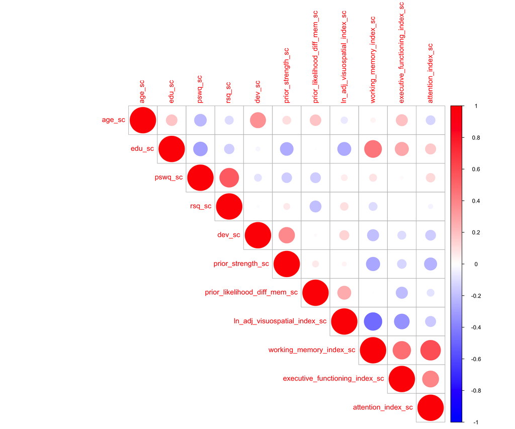

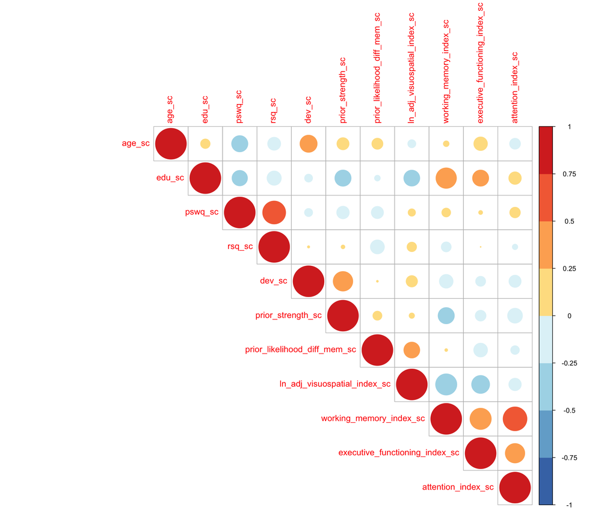

## Cognition Regression - individual cognitive measures

```
##
## Call:
## lm(formula = dev_sc ~ ln_adj_visuospatial_index_sc + working_memory_index_sc +
##     executive_functioning_index_sc + attention_index_sc, data = dat3_cog)
##
## Residuals:
##     Min      1Q  Median      3Q     Max
## -1.8382 -0.8030  0.1083  0.7075  2.4922
##
## Coefficients:
##                                 Estimate Std. Error t value Pr(>|t|)
## (Intercept)                     0.109573   0.150777   0.727    0.470
## ln_adj_visuospatial_index_sc    0.069514   0.156836   0.443    0.659
## working_memory_index_sc        -0.151123   0.223624  -0.676    0.502
## executive_functioning_index_sc  0.008529   0.203150   0.042    0.967
## attention_index_sc             -0.078905   0.179165  -0.440    0.661
##
## Residual standard error: 1.112 on 57 degrees of freedom
##   (23 observations deleted due to missingness)
## Multiple R-squared:  0.04547,    Adjusted R-squared:  -0.02151
## F-statistic: 0.6788 on 4 and 57 DF,  p-value: 0.6095
```

```
##   ln_adj_visuospatial_index_sc        working_memory_index_sc
##                       1.372107                       2.105070
## executive_functioning_index_sc             attention_index_sc
##                       1.373361                       1.662439
```

```
##   ln_adj_visuospatial_index_sc        working_memory_index_sc
##                       1.372107                       2.105070
## executive_functioning_index_sc             attention_index_sc
##                       1.373361                       1.662439
```

```
##
## Call:
## lm(formula = prior_strength_sc ~ ln_adj_visuospatial_index_sc +
##     working_memory_index_sc + executive_functioning_index_sc +
##     attention_index_sc, data = dat3_cog)
##
## Residuals:
##      Min       1Q   Median       3Q      Max
## -1.51850 -0.87641 -0.01143  0.66098  1.97192
##
## Coefficients:
##                                 Estimate Std. Error t value Pr(>|t|)
## (Intercept)                     0.122711   0.131194   0.935    0.354
## ln_adj_visuospatial_index_sc   -0.106627   0.136466  -0.781    0.438
## working_memory_index_sc        -0.303643   0.194580  -1.561    0.124
## executive_functioning_index_sc  0.008483   0.176764   0.048    0.962
## attention_index_sc             -0.082506   0.155895  -0.529    0.599
##
## Residual standard error: 0.9674 on 57 degrees of freedom
##   (23 observations deleted due to missingness)
## Multiple R-squared:  0.09514,    Adjusted R-squared:  0.03164
## F-statistic: 1.498 on 4 and 57 DF,  p-value: 0.2148
```

```
##   ln_adj_visuospatial_index_sc        working_memory_index_sc
##                       1.372107                       2.105070
## executive_functioning_index_sc             attention_index_sc
##                       1.373361                       1.662439
```

```
##
## Call:
## lm(formula = prior_likelihood_diff_mem_sc ~ ln_adj_visuospatial_index_sc +
##     working_memory_index_sc + executive_functioning_index_sc +
##     attention_index_sc, data = dat3_cog)
##
## Residuals:
##     Min      1Q  Median      3Q     Max
## -2.6023 -0.3121  0.1724  0.6044  1.9823
##
## Coefficients:
##                                Estimate Std. Error t value Pr(>|t|)
## (Intercept)                     -0.1038     0.1352  -0.768   0.4457
## ln_adj_visuospatial_index_sc     0.3416     0.1406   2.429   0.0183 *
## working_memory_index_sc          0.4106     0.2005   2.048   0.0452 *
## executive_functioning_index_sc  -0.2431     0.1821  -1.335   0.1872
## attention_index_sc              -0.1674     0.1606  -1.042   0.3017
## ---
## Signif. codes:  0 '***' 0.001 '**' 0.01 '*' 0.05 '.' 0.1 ' ' 1
##
## Residual standard error: 0.9968 on 57 degrees of freedom
##   (23 observations deleted due to missingness)
## Multiple R-squared:  0.1485, Adjusted R-squared:  0.0887
## F-statistic: 2.484 on 4 and 57 DF,  p-value: 0.05364
```

```
##
## Call:
## lm(formula = dev_sc ~ ln_adj_visuospatial_index_sc + working_memory_index_sc +
##     executive_functioning_index_sc + attention_index_sc + pswq_sc +
##     rsq_sc, data = dat3_cog)
##
## Residuals:
##     Min      1Q  Median      3Q     Max
## -1.8400 -0.8289  0.1505  0.7126  2.3878
##
## Coefficients:
##                                 Estimate Std. Error t value Pr(>|t|)
## (Intercept)                     0.104979   0.154569   0.679    0.500
## ln_adj_visuospatial_index_sc    0.077051   0.159977   0.482    0.632
## working_memory_index_sc        -0.142271   0.229933  -0.619    0.539
## executive_functioning_index_sc  0.005295   0.207227   0.026    0.980
## attention_index_sc             -0.071881   0.182515  -0.394    0.695
## pswq_sc                        -0.077494   0.172623  -0.449    0.655
## rsq_sc                          0.008753   0.198649   0.044    0.965
##
## Residual standard error: 1.129 on 55 degrees of freedom
##   (23 observations deleted due to missingness)
## Multiple R-squared:  0.05002,    Adjusted R-squared:  -0.05362
## F-statistic: 0.4826 on 6 and 55 DF,  p-value: 0.8184
```

```
##
## Call:
## lm(formula = prior_strength_sc ~ ln_adj_visuospatial_index_sc +
##     working_memory_index_sc + executive_functioning_index_sc +
##     attention_index_sc + pswq_sc + rsq_sc, data = dat3_cog)
##
## Residuals:
##      Min       1Q   Median       3Q      Max
## -1.38148 -0.82910  0.00618  0.69119  1.94880
##
## Coefficients:
##                                Estimate Std. Error t value Pr(>|t|)
## (Intercept)                     0.12988    0.13275   0.978    0.332
## ln_adj_visuospatial_index_sc   -0.09637    0.13740  -0.701    0.486
## working_memory_index_sc        -0.26526    0.19748  -1.343    0.185
## executive_functioning_index_sc -0.01077    0.17798  -0.061    0.952
## attention_index_sc             -0.06816    0.15675  -0.435    0.665
## pswq_sc                        -0.18903    0.14826  -1.275    0.208
## rsq_sc                          0.16552    0.17061   0.970    0.336
##
## Residual standard error: 0.9698 on 55 degrees of freedom
##   (23 observations deleted due to missingness)
## Multiple R-squared:  0.1226, Adjusted R-squared:  0.02692
## F-statistic: 1.281 on 6 and 55 DF,  p-value: 0.2811
```

```
##
## Call:
## lm(formula = prior_likelihood_diff_mem_sc ~ ln_adj_visuospatial_index_sc +
##     working_memory_index_sc + executive_functioning_index_sc +
##     attention_index_sc + pswq_sc + rsq_sc, data = dat3_cog)
##
## Residuals:
##     Min      1Q  Median      3Q     Max
## -2.4587 -0.3408  0.1944  0.5793  1.9283
##
## Coefficients:
##                                Estimate Std. Error t value Pr(>|t|)
## (Intercept)                     -0.1328     0.1349  -0.984   0.3292
## ln_adj_visuospatial_index_sc     0.3628     0.1397   2.597   0.0120 *
## working_memory_index_sc          0.4038     0.2007   2.011   0.0492 *
## executive_functioning_index_sc  -0.2343     0.1809  -1.295   0.2006
## attention_index_sc              -0.1534     0.1593  -0.963   0.3398
## pswq_sc                         -0.1171     0.1507  -0.777   0.4403
## rsq_sc                          -0.1601     0.1734  -0.923   0.3599
## ---
## Signif. codes:  0 '***' 0.001 '**' 0.01 '*' 0.05 '.' 0.1 ' ' 1
##
## Residual standard error: 0.9858 on 55 degrees of freedom
##   (23 observations deleted due to missingness)
## Multiple R-squared:  0.1963, Adjusted R-squared:  0.1086
## F-statistic: 2.239 on 6 and 55 DF,  p-value: 0.05276
```

```
## Linear mixed model fit by REML ['lmerMod']
## Formula: dev ~ ln_adj_visuospatial_index_sc + working_memory_index_sc +
##     executive_functioning_index_sc + attention_index_sc + (1 |      subject)
##    Data: .
##
## REML criterion at convergence: 18822
##
## Scaled residuals:
##     Min      1Q  Median      3Q     Max
## -1.3379 -0.6731 -0.1814  0.3354  5.7764
##
## Random effects:
##  Groups   Name        Variance Std.Dev.
##  subject  (Intercept) 0.04988  0.2233
##  Residual             0.97675  0.9883
## Number of obs: 6640, groups:  subject, 62
##
## Fixed effects:
##                                 Estimate Std. Error t value
## (Intercept)                     0.022908   0.032947   0.695
## ln_adj_visuospatial_index_sc    0.016118   0.034245   0.471
## working_memory_index_sc        -0.063102   0.048849  -1.292
## executive_functioning_index_sc -0.004043   0.044390  -0.091
## attention_index_sc             -0.012521   0.039155  -0.320
##
## Correlation of Fixed Effects:
##             (Intr) ln____ wrk___ exc___
## ln_dj_vss__ -0.016
## wrkng_mmr__ -0.144  0.418
## exctv_fnc__ -0.003  0.182 -0.212
## attntn_ndx_ -0.145 -0.197 -0.533 -0.193
```

```
##                                    Estimate Std..Error     t.value      p
## (Intercept)                     0.022908043 0.03294661  0.69530813 0.4869
## ln_adj_visuospatial_index_sc    0.016118443 0.03424548  0.47067352 0.6379
## working_memory_index_sc        -0.063101830 0.04884945 -1.29176125 0.1964
## executive_functioning_index_sc -0.004042768 0.04438991 -0.09107403 0.9274
## attention_index_sc             -0.012521009 0.03915495 -0.31978100 0.7491
```

```
## Linear mixed model fit by REML ['lmerMod']
## Formula: dev ~ ln_adj_visuospatial_index_sc + (1 | subject)
##    Data: .
##
## REML criterion at convergence: 18812.1
##
## Scaled residuals:
##     Min      1Q  Median      3Q     Max
## -1.3298 -0.6780 -0.1770  0.3455  5.7774
##
## Random effects:
##  Groups   Name        Variance Std.Dev.
##  subject  (Intercept) 0.05075  0.2253
##  Residual             0.97674  0.9883
## Number of obs: 6640, groups:  subject, 62
##
## Fixed effects:
##                              Estimate Std. Error t value
## (Intercept)                  0.002362   0.031313   0.075
## ln_adj_visuospatial_index_sc 0.045133   0.029448   1.533
##
## Correlation of Fixed Effects:
##             (Intr)
## ln_dj_vss__ 0.119
```

```
##                                 Estimate Std..Error    t.value      p
## (Intercept)                  0.002362375 0.03131267 0.07544471 0.9399
## ln_adj_visuospatial_index_sc 0.045133493 0.02944815 1.53264266 0.1254
```

```
## Linear mixed model fit by REML ['lmerMod']
## Formula: dev ~ working_memory_index_sc + (1 | subject)
##    Data: .
##
## REML criterion at convergence: 18808.2
##
## Scaled residuals:
##     Min      1Q  Median      3Q     Max
## -1.3395 -0.6720 -0.1809  0.3341  5.7809
##
## Random effects:
##  Groups   Name        Variance Std.Dev.
##  subject  (Intercept) 0.04724  0.2174
##  Residual             0.97675  0.9883
## Number of obs: 6640, groups:  subject, 62
##
## Fixed effects:
##                         Estimate Std. Error t value
## (Intercept)              0.02181    0.03182   0.685
## working_memory_index_sc -0.08193    0.03290  -2.490
##
## Correlation of Fixed Effects:
##             (Intr)
## wrkng_mmr__ -0.318
```

```
##                            Estimate Std..Error    t.value      p
## (Intercept)              0.02180559 0.03181592  0.6853675 0.4931
## working_memory_index_sc -0.08192931 0.03290204 -2.4900979 0.0128
```

```
## Linear mixed model fit by REML ['lmerMod']
## Formula: dev ~ executive_functioning_index_sc + (1 | subject)
##    Data: .
##
## REML criterion at convergence: 18812.1
##
## Scaled residuals:
##     Min      1Q  Median      3Q     Max
## -1.3313 -0.6757 -0.1811  0.3394  5.7784
##
## Random effects:
##  Groups   Name        Variance Std.Dev.
##  subject  (Intercept) 0.05128  0.2264
##  Residual             0.97675  0.9883
## Number of obs: 6640, groups:  subject, 62
##
## Fixed effects:
##                                 Estimate Std. Error t value
## (Intercept)                     0.004289   0.031747   0.135
## executive_functioning_index_sc -0.051187   0.038326  -1.336
##
## Correlation of Fixed Effects:
##             (Intr)
## exctv_fnc__ -0.180
```

```
##                                    Estimate Std..Error   t.value      p
## (Intercept)                     0.004289167 0.03174692  0.135105 0.8925
## executive_functioning_index_sc -0.051186664 0.03832573 -1.335569 0.1817
```

```
## Linear mixed model fit by REML ['lmerMod']
## Formula: dev ~ attention_index_sc + (1 | subject)
##    Data: .
##
## REML criterion at convergence: 18811.6
##
## Scaled residuals:
##     Min      1Q  Median      3Q     Max
## -1.3314 -0.6743 -0.1812  0.3388  5.7734
##
## Random effects:
##  Groups   Name        Variance Std.Dev.
##  subject  (Intercept) 0.05037  0.2244
##  Residual             0.97674  0.9883
## Number of obs: 6640, groups:  subject, 62
##
## Fixed effects:
##                    Estimate Std. Error t value
## (Intercept)         0.01373    0.03265   0.421
## attention_index_sc -0.05061    0.03047  -1.661
##
## Correlation of Fixed Effects:
##             (Intr)
## attntn_ndx_ -0.315
```

```
##                       Estimate Std..Error    t.value      p
## (Intercept)         0.01373098 0.03265384  0.4205011 0.6741
## attention_index_sc -0.05060746 0.03046587 -1.6611201 0.0967
```

```
## Linear mixed model fit by REML ['lmerMod']
## Formula:
## prior_strength ~ ln_adj_visuospatial_index_sc + working_memory_index_sc +
##     executive_functioning_index_sc + attention_index_sc + (1 |      subject)
##    Data: .
##
## REML criterion at convergence: 1906.3
##
## Scaled residuals:
##      Min       1Q   Median       3Q      Max
## -2.91715 -0.76321  0.06216  0.83886  2.12032
##
## Random effects:
##  Groups   Name        Variance Std.Dev.
##  subject  (Intercept) 0.3342   0.5781
##  Residual             0.6487   0.8054
## Number of obs: 738, groups:  subject, 62
##
## Fixed effects:
##                                Estimate Std. Error t value
## (Intercept)                     0.05102    0.08457   0.603
## ln_adj_visuospatial_index_sc   -0.08305    0.08791  -0.945
## working_memory_index_sc        -0.11625    0.12539  -0.927
## executive_functioning_index_sc  0.01414    0.11394   0.124
## attention_index_sc             -0.09174    0.10050  -0.913
##
## Correlation of Fixed Effects:
##             (Intr) ln____ wrk___ exc___
## ln_dj_vss__ -0.016
## wrkng_mmr__ -0.144  0.418
## exctv_fnc__ -0.003  0.182 -0.212
## attntn_ndx_ -0.145 -0.197 -0.533 -0.193
```

```
##                                   Estimate Std..Error    t.value      p
## (Intercept)                     0.05102106 0.08456576  0.6033300 0.5463
## ln_adj_visuospatial_index_sc   -0.08305258 0.08790862 -0.9447605 0.3448
## working_memory_index_sc        -0.11624896 0.12538981 -0.9271005 0.3539
## executive_functioning_index_sc  0.01414295 0.11393812  0.1241283 0.9012
## attention_index_sc             -0.09174097 0.10049914 -0.9128532 0.3613
```

```
## Linear mixed model fit by REML ['lmerMod']
## Formula: prior_strength ~ ln_adj_visuospatial_index_sc + (1 | subject)
##    Data: .
##
## REML criterion at convergence: 1902.3
##
## Scaled residuals:
##      Min       1Q   Median       3Q      Max
## -2.87827 -0.75484  0.07954  0.83624  2.12974
##
## Random effects:
##  Groups   Name        Variance Std.Dev.
##  subject  (Intercept) 0.3419   0.5847
##  Residual             0.6487   0.8054
## Number of obs: 738, groups:  subject, 62
##
## Fixed effects:
##                               Estimate Std. Error t value
## (Intercept)                  -0.006158   0.080566  -0.076
## ln_adj_visuospatial_index_sc -0.024367   0.075779  -0.322
##
## Correlation of Fixed Effects:
##             (Intr)
## ln_dj_vss__ 0.119
```

```
##                                  Estimate Std..Error     t.value      p
## (Intercept)                  -0.006157536 0.08056605 -0.07642843 0.9391
## ln_adj_visuospatial_index_sc -0.024367010 0.07577942 -0.32155182 0.7478
```

```
## Linear mixed model fit by REML ['lmerMod']
## Formula: prior_strength ~ working_memory_index_sc + (1 | subject)
##    Data: .
##
## REML criterion at convergence: 1900.1
##
## Scaled residuals:
##      Min       1Q   Median       3Q      Max
## -2.89265 -0.76232  0.05638  0.83898  2.10778
##
## Random effects:
##  Groups   Name        Variance Std.Dev.
##  subject  (Intercept) 0.3289   0.5735
##  Residual             0.6486   0.8054
## Number of obs: 738, groups:  subject, 62
##
## Fixed effects:
##                         Estimate Std. Error t value
## (Intercept)              0.03565    0.08298   0.430
## working_memory_index_sc -0.12585    0.08582  -1.466
##
## Correlation of Fixed Effects:
##             (Intr)
## wrkng_mmr__ -0.318
```

```
##                            Estimate Std..Error    t.value      p
## (Intercept)              0.03565427 0.08298095  0.4296681 0.6674
## working_memory_index_sc -0.12585148 0.08581780 -1.4664962 0.1425
```

```
## Linear mixed model fit by REML ['lmerMod']
## Formula: prior_strength ~ executive_functioning_index_sc + (1 | subject)
##    Data: .
##
## REML criterion at convergence: 1901.6
##
## Scaled residuals:
##      Min       1Q   Median       3Q      Max
## -2.87549 -0.76472  0.07643  0.82628  2.12185
##
## Random effects:
##  Groups   Name        Variance Std.Dev.
##  subject  (Intercept) 0.3404   0.5834
##  Residual             0.6487   0.8054
## Number of obs: 738, groups:  subject, 62
##
## Fixed effects:
##                                 Estimate Std. Error t value
## (Intercept)                     0.005483   0.081173   0.068
## executive_functioning_index_sc -0.057193   0.097993  -0.584
##
## Correlation of Fixed Effects:
##             (Intr)
## exctv_fnc__ -0.180
```

```
##                                    Estimate Std..Error     t.value      p
## (Intercept)                     0.005483168 0.08117289  0.06754925 0.9461
## executive_functioning_index_sc -0.057193393 0.09799299 -0.58364778 0.5595
```

```
## Linear mixed model fit by REML ['lmerMod']
## Formula: prior_strength ~ attention_index_sc + (1 | subject)
##    Data: .
##
## REML criterion at convergence: 1899.3
##
## Scaled residuals:
##      Min       1Q   Median       3Q      Max
## -2.89786 -0.77748  0.06375  0.84212  2.08590
##
## Random effects:
##  Groups   Name        Variance Std.Dev.
##  subject  (Intercept) 0.3228   0.5682
##  Residual             0.6487   0.8054
## Number of obs: 738, groups:  subject, 62
##
## Fixed effects:
##                    Estimate Std. Error t value
## (Intercept)         0.04278    0.08223   0.520
## attention_index_sc -0.13570    0.07673  -1.769
##
## Correlation of Fixed Effects:
##             (Intr)
## attntn_ndx_ -0.315
```

```
##                       Estimate Std..Error    t.value      p
## (Intercept)         0.04277685 0.08223306  0.5201904 0.6029
## attention_index_sc -0.13570460 0.07673253 -1.7685406 0.0770
```

```
##
## Call:
## lm(formula = prior_likelihood_diff_mem ~ ln_adj_visuospatial_index_sc +
##     working_memory_index_sc + executive_functioning_index_sc +
##     attention_index_sc, data = .)
##
## Residuals:
##     Min      1Q  Median      3Q     Max
## -2.4079 -0.3198  0.1603  0.6371  1.9562
##
## Coefficients:
##                                Estimate Std. Error t value Pr(>|t|)
## (Intercept)                    -0.10481    0.13524  -0.775   0.4416
## ln_adj_visuospatial_index_sc    0.35237    0.13982   2.520   0.0146 *
## working_memory_index_sc         0.31725    0.20336   1.560   0.1244
## executive_functioning_index_sc -0.22542    0.18140  -1.243   0.2192
## attention_index_sc             -0.07423    0.16360  -0.454   0.6518
## ---
## Signif. codes:  0 '***' 0.001 '**' 0.01 '*' 0.05 '.' 0.1 ' ' 1
##
## Residual standard error: 0.991 on 56 degrees of freedom
##   (23 observations deleted due to missingness)
## Multiple R-squared:  0.1436, Adjusted R-squared:  0.0824
## F-statistic: 2.347 on 4 and 56 DF,  p-value: 0.06548
```

```
##
## Call:
## lm(formula = prior_likelihood_diff_mem ~ ln_adj_visuospatial_index_sc,
##     data = .)
##
## Residuals:
##     Min      1Q  Median      3Q     Max
## -2.7531 -0.3025  0.2915  0.6457  1.5575
##
## Coefficients:
##                              Estimate Std. Error t value Pr(>|t|)
## (Intercept)                  -0.06831    0.12821  -0.533   0.5962
## ln_adj_visuospatial_index_sc  0.29449    0.11976   2.459   0.0169 *
## ---
## Signif. codes:  0 '***' 0.001 '**' 0.01 '*' 0.05 '.' 0.1 ' ' 1
##
## Residual standard error: 0.9936 on 59 degrees of freedom
##   (23 observations deleted due to missingness)
## Multiple R-squared:  0.09296,    Adjusted R-squared:  0.07758
## F-statistic: 6.046 on 1 and 59 DF,  p-value: 0.01689
```

```
##
## Call:
## lm(formula = prior_likelihood_diff_mem ~ visuospatial_index_sc,
##     data = .)
##
## Residuals:
##     Min      1Q  Median      3Q     Max
## -2.6796 -0.4513  0.2488  0.7173  1.6157
##
## Coefficients:
##                       Estimate Std. Error t value Pr(>|t|)
## (Intercept)           -0.08223    0.12899  -0.637   0.5263
## visuospatial_index_sc -0.25989    0.11879  -2.188   0.0327 *
## ---
## Signif. codes:  0 '***' 0.001 '**' 0.01 '*' 0.05 '.' 0.1 ' ' 1
##
## Residual standard error: 1.003 on 59 degrees of freedom
##   (23 observations deleted due to missingness)
## Multiple R-squared:  0.07504,    Adjusted R-squared:  0.05936
## F-statistic: 4.786 on 1 and 59 DF,  p-value: 0.03266
```

```
##
## Call:
## lm(formula = prior_likelihood_diff_mem ~ working_memory_index_sc,
##     data = .)
##
## Residuals:
##     Min      1Q  Median      3Q     Max
## -2.5017 -0.4956  0.2006  0.7216  1.8887
##
## Coefficients:
##                         Estimate Std. Error t value Pr(>|t|)
## (Intercept)              -0.1005     0.1413  -0.711     0.48
## working_memory_index_sc  -0.0219     0.1450  -0.151     0.88
##
## Residual standard error: 1.043 on 59 degrees of freedom
##   (23 observations deleted due to missingness)
## Multiple R-squared:  0.0003865,  Adjusted R-squared:  -0.01656
## F-statistic: 0.02281 on 1 and 59 DF,  p-value: 0.8805
```

```
##
## Call:
## lm(formula = prior_likelihood_diff_mem ~ executive_functioning_index_sc,
##     data = .)
##
## Residuals:
##     Min      1Q  Median      3Q     Max
## -2.1640 -0.3832  0.2195  0.5741  1.9337
##
## Coefficients:
##                                Estimate Std. Error t value Pr(>|t|)
## (Intercept)                    -0.07151    0.13300  -0.538    0.593
## executive_functioning_index_sc -0.24701    0.15967  -1.547    0.127
##
## Residual standard error: 1.023 on 59 degrees of freedom
##   (23 observations deleted due to missingness)
## Multiple R-squared:  0.03898,    Adjusted R-squared:  0.02269
## F-statistic: 2.393 on 1 and 59 DF,  p-value: 0.1272
```

```
##
## Call:
## lm(formula = prior_likelihood_diff_mem ~ attention_index_sc,
##     data = .)
##
## Residuals:
##     Min      1Q  Median      3Q     Max
## -2.4959 -0.4813  0.1410  0.7543  1.8960
##
## Coefficients:
##                    Estimate Std. Error t value Pr(>|t|)
## (Intercept)        -0.09704    0.13995  -0.693    0.491
## attention_index_sc -0.03262    0.13160  -0.248    0.805
##
## Residual standard error: 1.043 on 59 degrees of freedom
##   (23 observations deleted due to missingness)
## Multiple R-squared:  0.00104,    Adjusted R-squared:  -0.01589
## F-statistic: 0.06144 on 1 and 59 DF,  p-value: 0.8051
```

### Plots

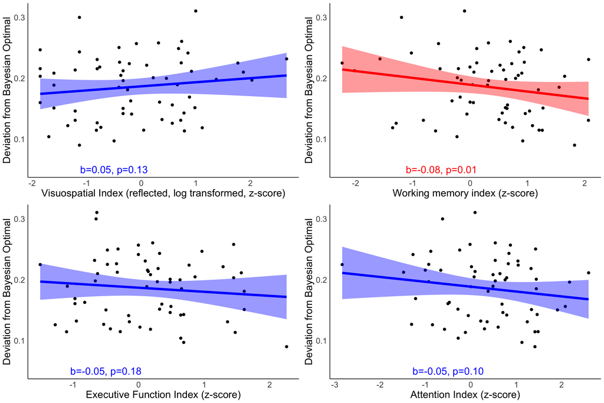

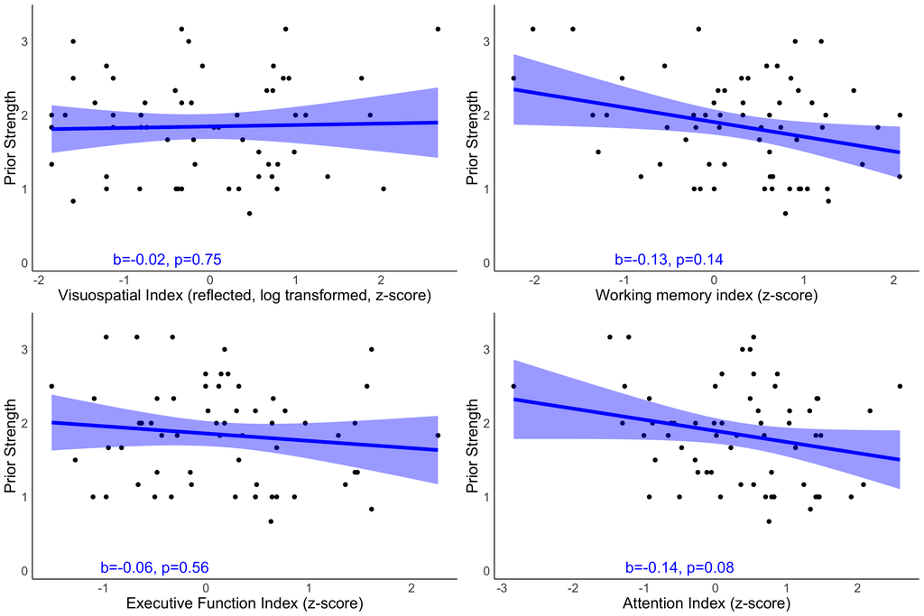

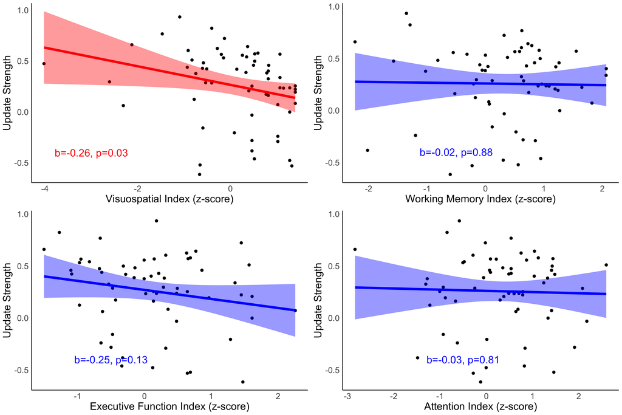